# Bayesian Basics

```r
library(tidyverse)
library(rethinking)
```

# Problema de juguete

Tiramos 9 veces un globo terráqueo al aire y anotamos si, al recogerlo con la mano, la punta dle dedo índice señala agua o tierra.

Lo hacemos 9 veces y obtenemos el siguiente resultado:

```
A T A A A T A T A
```

Es decir, 6 aguas y 3 tierras:

```r
N <- 9
k <- 6
```

Queremos estimar el % de superficie del globo correspondiente a “agua”.

# Modelado

Podemos modelar el problema con una distribución (función masa de probabilidad) binomial: dada la probabilidad $p$ (la fracción de superficie del globo correspondiente a “agua”), la probabilidad de obtener $k$ “aguas” en $N$ intentos:

$$\Pr(N, k, p) =
\begin{pmatrix}
N \\
k
\end{pmatrix} p^k (1 - p)^{N-k}$$

Pero $p$, a su vez, es desconocida, es el parámetro que queremos estimar a partir de los datos. Supongamos “a priori” que el parámetro $p$ sigue una función densidad de probabilidad uniforme:

$$f(p) =
\begin{cases}
1 & 0 \leq p \leq 1 \\
0 & p < 0, p > 1
\end{cases}$$

Lo que tratamos de estimar a partir de los datos obtenidos (“a posteriori”) es, aplicando el teorema de Bayes:

$$\Pr(p|N = 9, k = 6) = \frac{\Pr(N = 9, k = 6 | p) \Pr(p)}{\Pr(N = 9, k = 6)}$$

Hay varias formas de estimar la distribución posterior. En este caso solo hay 1 parámetro y, a efectos ilustrativos, funcionará el método *grid*.

```r
L_GRID <- 100

p_grid <- seq(0, 1, length.out = L_GRID)

prior <- dunif(p_grid)

likelihood <- dbinom(x = k, size = N, prob = p_grid)

posterior <- likelihood * prior / sum(likelihood * prior)
```

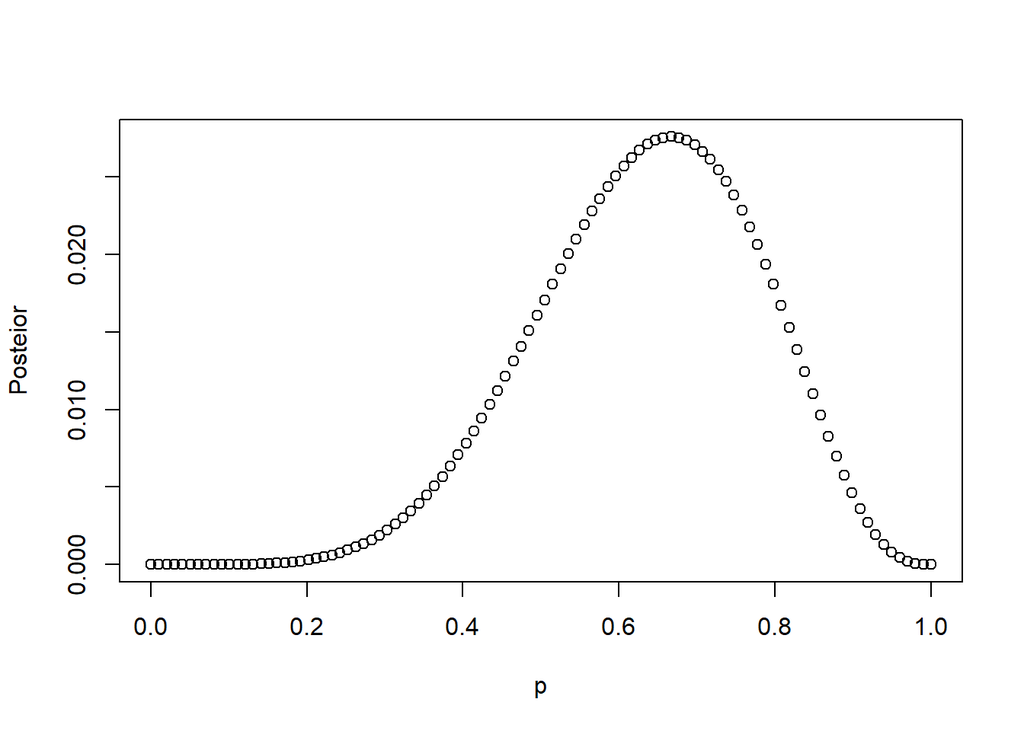

```r
plot(p_grid, posterior, type = "b",
     ylab = "Posteior", xlab = "p")
```

# Muestreo de la posterior

Lo más frecuente será no poder estimar directamente la distribución posterior, pero si - contraintiuitivamente - obtener muestras de ella.

En nuestro caso:

```r
L_POST_SAMPLE <- 1e4
samples <- sample(x = p_grid,
                  size = L_POST_SAMPLE,
                  replace = TRUE,
                  prob = posterior)
```

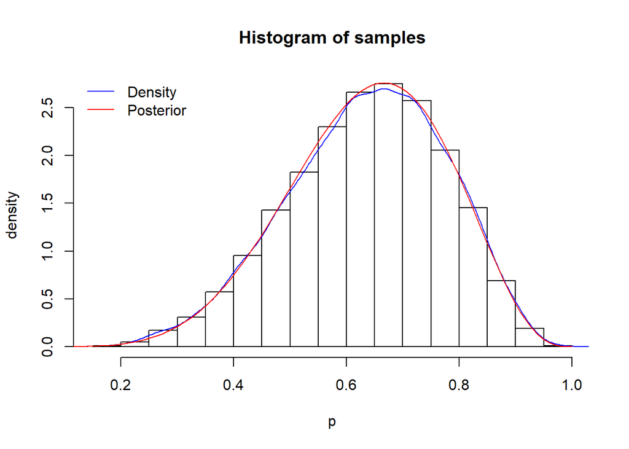

```r
hist(samples, freq = FALSE,
     xlab = "p", ylab = "density")
lines(density(samples), col = "blue")
lines(p_grid, L_GRID*posterior, col = "red")
legend("topleft", legend = c("Density", "Posterior"),
       lty = 1, col = c("blue", "red"), bty = "n")
```

Esta muestra de la posterior es el estimador que nos ofrece este enfoque.

# Resúmenes del estimador

## Entre límites

Probabilidad de que la proporción de agua sea menor que 50%:

- De la distribución posterior:

```r
sum(posterior[p_grid < 0.5])
```

```
## [1] 0.1718331
```

- A partir de la muestra de la distribución posterior:

```r
sum(samples < 0.5) / length(samples)
```

```
## [1] 0.1748
```

Cuál es la probabilidad de que la proporción de agua esté entre 50 y 75%:

```r
sum(posterior[p_grid > 0.5 & p_grid < .75])
```

```
## [1] 0.6099515
```

```r
sum(samples > 0.5 & p_grid < .75 ) / length(samples)
```

```
## [1] 0.6203
```

## Masa de probabilidad

Entre qué valores de $p$ se encuentra el 80% inferior de la probabilidad posterior:

```r
quantile(samples, .8)
```

```
##       80%
## 0.7575758
```

80% central de la probabilidad posterior (es un *percentile interval*, PI):

```r
quantile(samples, c(0.1, 0.9))
```

```
##       10%       90%
## 0.4444444 0.8181818
```

Si la muestra está sesgada mejor usar los *Highest Posterior Density Intervals*, el intervalo *más estrecho* de probabilidades posteriores que contenga la masa de probabilidad que se especifique.

Por ejemplo:

```r
HPDI(samples, 0.8)
```

```
##      |0.8      0.8|
## 0.4747475 0.8282828
```

(Es muy parecido al PI porque esta muestra no está muy sesgada)